# R Notebook

```r
data(swiss)
?swiss
```

> Remark: We observe here that ‘hclust’ can be applied to any type of data if we are able to compute for these data. Conversely, kmeans is restricted to continuous data due to the need to compute centers.

> Exercises: Apply the different methods (group distances) of HC to compare the results.

```r
library(class)
?hclust
D = dist(swiss)

par(mfrow=c(2,2))
hc1 = hclust(D, method="complete"); plot(hc1)
hc2 = hclust(D, method="single"); plot(hc2)
```

[figure not shown]

```r
hc3 = hclust(D, method="centroid"); plot(hc3)
hc4 = hclust(D, method="ward.D2");plot(hc4)
```

```r
install.packages("cluter")
#install.packages("factoextra")
#install.packages("gridExtra")
library(tidyverse)
library(cluter)
```

```
Error in library(cluter) : there is no package called ‘cluter’
```

```r
kmeans2 <- kmeans(as.matrix(swiss), centers=2)
```

> Remark: we can see here that the different methods lead to quite different dendrogram, leading in turn to different choices of numbers of clusters. Good analysis is the one which helps analyst; you need to be clear with those analysis by yourself Let’s remember that the clustering aims to help the analyst to understand the data. The choice of a method should be done according to this idea!

> A good way to verify that the different clustering make sense or not is to visualize the data with the clustering as an additional information (thanks to the colors)

```r
hc4=hclust(D,method="ward.D2")
cl4=cutree(hc4, k=2)
cl4
```

```
  Courtelary     Delemont Franches-Mnt
           1            2            2
     Moutier   Neuveville   Porrentruy
           1            1            2
       Broye        Glane      Gruyere
           2            2            2
      Sarine      Veveyse        Aigle
           2            2            1
     Aubonne     Avenches     Cossonay
           1            1            1
   Echallens     Grandson     Lausanne
           1            1            1
   La Vallee       Lavaux       Morges
           1            1            1
      Moudon        Nyone         Orbe
           1            1            1
        Oron      Payerne Paysd'enhaut
           1            1            1
       Rolle        Vevey      Yverdon
           1            1            1
     Conthey    Entremont       Herens
           2            2            2
    Martigwy      Monthey   St Maurice
           2            2            2
      Sierre         Sion       Boudry
           2            2            1
La Chauxdfnd     Le Locle    Neuchatel
           1            1            1
  Val de Ruz ValdeTravers V. De Geneve
           1            1            1
 Rive Droite  Rive Gauche
           1            1
```

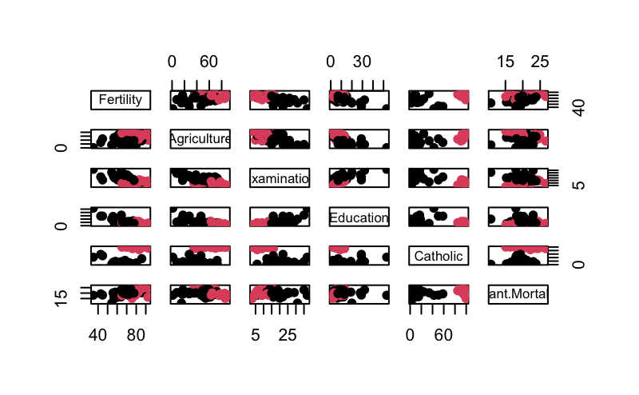

```r
plot(swiss, col=cl4, pch=19)
```

```r
cl1 = cutree(hc1, k=3)
cl2 = cutree(hc2, k=4)
cl3 = cutree(hc3, k=3)
par(mfrow=c(2,2))
plot(swiss[, c(3,5)], col=cl1, pch=19, main="Complete")
# Charles likes single linkage
plot(swiss[, c(3,5)], col=cl1, pch=19, main="Single")
```

[figure not shown]

```r
plot(swiss[, c(3,5)], col=cl1, pch=19, main="Centroid")
plot(swiss[, c(3,5)], col=cl1, pch=19, main="Ward")
```

## Kmeans

Let’s now have a look at the same data with kmeans

```r
?kmeans
```

```r
data(swiss)
out=kmeans(swiss, centers=3)
out
```

```
K-means clustering with 3 clusters of sizes 11, 16, 20

Cluster means:
  Fertility Agriculture Examination Education Catholic Infant.Mortality
1  58.30909    19.50909    25.72727    23.000 22.21455         19.22727
2  80.55000    65.51875     9.43750     6.625 96.15000         20.77500
3  68.32500    55.90500    17.05000     7.850  7.55000         19.67000

Clustering vector:
  Courtelary     Delemont Franches-Mnt      Moutier   Neuveville   Porrentruy
           1            2            2            3            3            2
       Broye        Glane      Gruyere       Sarine      Veveyse        Aigle
           2            2            2            2            2            3
     Aubonne     Avenches     Cossonay    Echallens     Grandson     Lausanne
           3            3            3            3            3            1
   La Vallee       Lavaux       Morges       Moudon        Nyone         Orbe
           1            3            3            3            3            3
        Oron      Payerne Paysd'enhaut        Rolle        Vevey      Yverdon
           3            3            3            3            1            3
     Conthey    Entremont       Herens     Martigwy      Monthey   St Maurice
           2            2            2            2            2            2
      Sierre         Sion       Boudry La Chauxdfnd     Le Locle    Neuchatel
           2            2            3            1            1            1
  Val de Ruz ValdeTravers V. De Geneve  Rive Droite  Rive Gauche
           3            1            1            1            1

Within cluster sum of squares by cluster:
[1] 9116.894 6532.906 5966.297
 (between_SS / total_SS =  81.8 %)

Available components:

[1] "cluster"      "centers"      "totss"        "withinss"     "tot.withinss"
[6] "betweenss"    "size"         "iter"         "ifault"
```

> Remark: K-means calculates the variance of each cluster

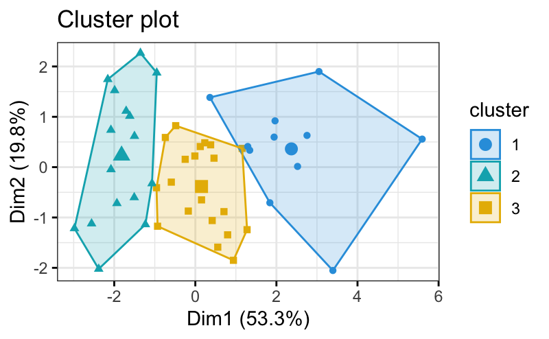

```r
library(factoextra)
fviz_cluster(out, data= swiss,
             palette = c("#2E9FDF", "#00AFBB", "#E7B800"),
             geom = "point",
             ellipse.type = "convex",
             ggtheme = theme_bw())
```

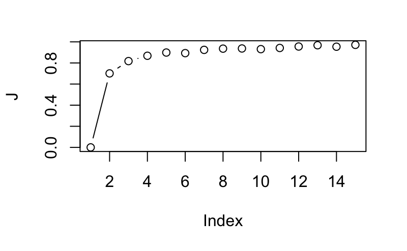

```r
J = rep(NA, 15)
for (k in 1:15){
  out = kmeans(swiss, center=k)
  J[k] = out$betweens/out$totss
}
plot(J, type="b")
```

> Remarks: K-means is sensitive to the initialization. We observe on this small run that curve can change with different initializations a nnd we can even observe non increasing curves for unlucky initializations. A way to avoid this initialization effect, we can average on several runs for each value of k:

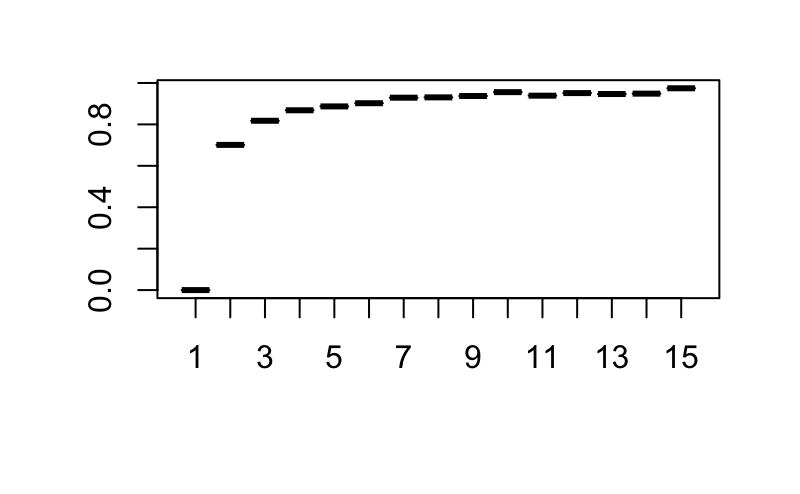

```r
J = matrix(NA, 10, 15)
for (k in 1:15){
  for (l in 1:10)
    out = kmeans(swiss, center=k)
    J[l, k] = out$betweens/out$totss
}
boxplot(J, type="b")
```

> On this example, I’d probabily pick $k^*=5$ as the most appropriate number of clusters.

> Exercise: visualize the clustering result with a pair plot and compare to the ones obtained with hclust

```r
out5 = kmeans(swiss, centers=5, nstart=10)
plot(swiss, col=out5$cluster, pch=19)
```

[output not shown]

```r
plot(swiss[,c(5,2)], col=out5$cluster, pch=19)
```

[output not shown]